# Lab 08 - Predicting rain

Daniel Gribben

2026-11-20

## Warm up - Spam or Not Spam?

```r
library(openintro)
glimpse(email)
```

```
## Rows: 3,921
## Columns: 21
## $ spam         <fct> 0, 0, 0, 0, 0, 0, 0, 0, 0, 0, 0, 0, 0, 0, 0, 0, 0, 0, 0, …
## $ to_multiple  <fct> 0, 0, 0, 0, 0, 0, 1, 1, 0, 0, 0, 0, 0, 0, 0, 0, 0, 0, 0, …
## $ from         <fct> 1, 1, 1, 1, 1, 1, 1, 1, 1, 1, 1, 1, 1, 1, 1, 1, 1, 1, 1, …
## $ cc           <int> 0, 0, 0, 0, 0, 0, 0, 1, 0, 0, 0, 1, 0, 1, 2, 1, 0, 2, 0, …
## $ sent_email   <fct> 0, 0, 0, 0, 0, 0, 1, 1, 0, 0, 1, 0, 0, 1, 0, 1, 0, 0, 1, …
## $ time         <dttm> 2012-01-01 06:16:41, 2012-01-01 07:03:59, 2012-01-01 16:…
## $ image        <dbl> 0, 0, 0, 0, 0, 0, 0, 1, 0, 0, 0, 0, 0, 0, 0, 0, 0, 0, 0, …
## $ attach       <dbl> 0, 0, 0, 0, 0, 0, 0, 1, 0, 0, 0, 0, 0, 0, 0, 0, 0, 0, 0, …
## $ dollar       <dbl> 0, 0, 4, 0, 0, 0, 0, 0, 0, 0, 0, 0, 0, 0, 2, 0, 5, 0, 0, …
## $ winner       <fct> no, no, no, no, no, no, no, no, no, no, no, no, no, no, n…
## $ inherit      <dbl> 0, 0, 1, 0, 0, 0, 0, 0, 0, 0, 0, 0, 0, 0, 0, 0, 0, 0, 0, …
## $ viagra       <dbl> 0, 0, 0, 0, 0, 0, 0, 0, 0, 0, 0, 0, 0, 0, 0, 0, 0, 0, 0, …
## $ password     <dbl> 0, 0, 0, 0, 2, 2, 0, 0, 0, 0, 0, 0, 0, 0, 0, 0, 1, 0, 0, …
## $ num_char     <dbl> 11.370, 10.504, 7.773, 13.256, 1.231, 1.091, 4.837, 7.421…
## $ line_breaks  <int> 202, 202, 192, 255, 29, 25, 193, 237, 69, 68, 25, 79, 191…
## $ format       <fct> 1, 1, 1, 1, 0, 0, 1, 1, 0, 1, 1, 0, 1, 1, 1, 1, 1, 1, 0, …
## $ re_subj      <fct> 0, 0, 0, 0, 0, 0, 0, 0, 0, 0, 0, 1, 0, 1, 1, 1, 0, 1, 1, …
## $ exclaim_subj <dbl> 0, 0, 0, 0, 0, 0, 0, 0, 0, 0, 0, 0, 0, 0, 0, 0, 1, 0, 0, …
## $ urgent_subj  <fct> 0, 0, 0, 0, 0, 0, 0, 0, 0, 0, 0, 0, 0, 0, 0, 0, 0, 0, 0, …
## $ exclaim_mess <dbl> 0, 1, 6, 48, 1, 1, 1, 18, 1, 0, 2, 1, 0, 10, 4, 10, 20, 0…
## $ number       <fct> big, small, small, small, none, none, big, small, small, …
```

1. What proportion of emails are spam? Calculate the proportion of spam separately for emails with and without the word “winner”.
2. Fit a logistic regression of `spam` on `winner` and write down the fitted model. Use `predict(..., type = "prob")` to find the predicted probability of spam for each group. Compare them with your previously calculated proportions.

```r
model<-logistic_reg()%>%
  set_engine("glm")%>%
  fit(spam~winner, data = email)

predict(model, email, type = "prob") %>%
  bind_cols(email)
```

```
## # A tibble: 3,921 × 23
##    .pred_0 .pred_1 spam  to_multiple from     cc sent_email time
##      <dbl>   <dbl> <fct> <fct>       <fct> <int> <fct>      <dttm>
##  1   0.910  0.0900 0     0           1         0 0          2012-01-01 06:16:41
##  2   0.910  0.0900 0     0           1         0 0          2012-01-01 07:03:59
##  3   0.910  0.0900 0     0           1         0 0          2012-01-01 16:00:32
##  4   0.910  0.0900 0     0           1         0 0          2012-01-01 09:09:49
##  5   0.910  0.0900 0     0           1         0 0          2012-01-01 10:00:01
##  6   0.910  0.0900 0     0           1         0 0          2012-01-01 10:04:46
##  7   0.910  0.0900 0     1           1         0 1          2012-01-01 17:55:06
##  8   0.910  0.0900 0     1           1         1 1          2012-01-01 18:45:21
##  9   0.910  0.0900 0     0           1         0 0          2012-01-01 21:08:59
## 10   0.910  0.0900 0     0           1         0 0          2012-01-01 18:12:00
## # ℹ 3,911 more rows
## # ℹ 15 more variables: image <dbl>, attach <dbl>, dollar <dbl>, winner <fct>,
## #   inherit <dbl>, viagra <dbl>, password <dbl>, num_char <dbl>,
## #   line_breaks <int>, format <fct>, re_subj <fct>, exclaim_subj <dbl>,
## #   urgent_subj <fct>, exclaim_mess <dbl>, number <fct>
```

3. How about fitting a logistic regression of `spam` on `winner` and `num_char`? Calculate the confusion matrix of the fitted logistic model on this new model, and compare with the confusion matrix result of the previous model, relying on `winner` only. Explain the differences on confusion matrix.

**Hint:** `augment()` adds the predicted class (`.pred_class`) to the data. It labels an email as spam when its predicted probability is above 0.5.

```r
weather <- read.csv("data/weatherAUS.csv", header = TRUE)
```

# Exercise 1: Exploratory Data Analysis

We will start by transform any character variables that need to be transformed into categorical. Use the following code to identify them and trasform them into factors.

```r
variables_to_transform = weather %>%
  select(where(is.character),-Date) %>% names()
weather <- weather %>%
  mutate_at(vars(all_of(variables_to_transform)),factor)
```

To simplify things, today we will not be using some categorical explanatory variables, because they have a very large number of categories and might make our model interpretation more complex. Specifically we will exclude `WindGustDir`, `WindDir9am` and `WindDir3pm`.

```r
weather <- weather %>%
  select(-WindGustDir,-WindDir9am,-WindDir3pm)
```

Note that some of these variables have a large number of missing values:

```r
weather %>%
  select(where(~ any(is.na(.)))) %>%
  summarise(across(everything(), ~mean(is.na(.)))) %>%
  pivot_longer(col = everything(), names_to = "Variable", values_to = "Prop_NA") %>%
  arrange(desc(Prop_NA))
```

```
## # A tibble: 18 × 2
##    Variable      Prop_NA
##    <chr>           <dbl>
##  1 Sunshine      0.480
##  2 Evaporation   0.432
##  3 Cloud3pm      0.408
##  4 Cloud9am      0.384
##  5 Pressure9am   0.104
##  6 Pressure3pm   0.103
##  7 WindGustSpeed 0.0706
##  8 Humidity3pm   0.0310
##  9 Temp3pm       0.0248
## 10 RainTomorrow  0.0225
## 11 Rainfall      0.0224
## 12 RainToday     0.0224
## 13 WindSpeed3pm  0.0211
## 14 Humidity9am   0.0182
## 15 WindSpeed9am  0.0121
## 16 Temp9am       0.0121
## 17 MinTemp       0.0102
## 18 MaxTemp       0.00867
```

1. Are there any missing values in our variable of interest `RainTomorrow`? If so, we filter them out and save the new dataset as `weather_noNA`.

```r
weather_noNA<-weather%>%
  filter(!is.na(RainTomorrow))
```

2. Which cities are the ones with more rain days? To do this, let’s analyze the `RainToday` variable.

```r
weather_noNA%>%
  group_by(Location)%>%
  filter(RainToday == "Yes")%>%
  count()
```

```
## # A tibble: 49 × 2
## # Groups:   Location [49]
##    Location          n
##    <fct>         <int>
##  1 Adelaide        676
##  2 Albany          893
##  3 Albury          615
##  4 AliceSprings    241
##  5 BadgerysCreek   572
##  6 Ballarat        778
##  7 Bendigo         562
##  8 Brisbane        704
##  9 Cairns          941
## 10 Canberra        624
## # ℹ 39 more rows
```

# Exercise 2: Logistic regression

We will focus our analysis on the city of `Portland`. Remove `eval=FALSE` from below once you have defined the object `weather_noNA`.

```r
weather_Portland <- weather_noNA %>%
  filter(Location == "Portland")
```

1. Try to predict `RainTomorrow` by fitting a linear regression using the variable `RainToday` and print the output using `tidy()`.

```r
linear_reg()%>%
  set_engine("lm")%>%
  fit(RainTomorrow ~ RainToday, data = weather_Portland)%>%
  tidy()
```

[output not shown]

2. For each point in our dataset, what are the fitted probabilities that tomorrow it’s going to rain?
- Plot them using an appropriate visualization. What is peculiar about them?

> Hint: how many unique values do the predicted probabilities take? What do these value correspond to?

- Are there any missing values? Why?

# Exercise 3: Split the data and build workflows

Let us set a seed and perform a split of our data.

```r
set.seed(111723)
```

1. Split the data into a training set (80% of your Portland data) and a testing set.

```r
set.seed(1234)
weather_split <- initial_split(weather_Portland, 0.8)
weather_train <- training(weather_split)
weather_test  <- testing(weather_split)
```

2. Refit the simple logistic regression using `RainToday` as predictor on this training data, using `tidymodels` recipes and workflows.
- Start by the recipe. First initialize the recipe, then remove observations with missing values using `step_naomit()` and finally use `step_dummy` to convert categorical to dummy variables.

```r
weather_rec1 <- recipe(
  RainTomorrow ~ RainToday,
  data = weather_train
  ) %>%
  step_naomit(all_predictors()) %>%
  step_dummy(all_nominal(), -all_outcomes())
```

- Build your workflow combining model and recipe

```r
weather_mod1 <- logistic_reg() %>%
  set_engine("glm")
weather_wflow1 <- workflow() %>% # initiate workflow
  add_model(weather_mod1) %>%                   # add model
  add_recipe(weather_rec1)                       # add recipe
```

- Now fit your model on the training data

```r
weather_fit1 <- weather_wflow1 %>%
  fit(data = weather_train)
tidy(weather_fit1)
```

```
## # A tibble: 2 × 5
##   term          estimate std.error statistic  p.value
##   <chr>            <dbl>     <dbl>     <dbl>    <dbl>
## 1 (Intercept)      -1.08    0.0589     -18.3 6.56e-75
## 2 RainToday_Yes     1.35    0.0905      14.9 3.23e-50
```

3. Fit now a multiple logistic regression, i.e. using multiple explanatory variables, to predict `RainTomorrow`. We will use as predictors the variables `MinTemp`, `MaxTemp`, `RainToday` and `Rainfall`. Similarly to question 2, use workflows to fit this model on our training data.
- Start by the recipe. This will be a simple recipe, because we have not done many pre-processing steps, but do remove missing values and transform categorical variables into dummy variables:

```r
weather_rec2 <- recipe(
  RainTomorrow ~ MinTemp+MaxTemp+RainToday+Rainfall, # include your formula
  data = weather_Portland
  ) %>%
  step_naomit(all_predictors()) %>%          # exclude cases with missing values in all
  step_dummy(all_nominal(), -all_outcomes()) # exclude all outcomes

weather_mod2 <- logistic_reg() %>%
  set_engine("glm")

weather_wflow2 <- workflow() %>%
  add_model(weather_mod2) %>%
  add_recipe(weather_rec2)
```

- Save the model, workflow and finally, let’s fit to the training data.

```r
weather_fit2 <- weather_wflow2 %>%
  fit(data = weather_train)
tidy(weather_fit1)
```

```
## # A tibble: 2 × 5
##   term          estimate std.error statistic  p.value
##   <chr>            <dbl>     <dbl>     <dbl>    <dbl>
## 1 (Intercept)      -1.08    0.0589     -18.3 6.56e-75
## 2 RainToday_Yes     1.35    0.0905      14.9 3.23e-50
```

3. Now let’s evaluate the predictive performance of these two models on our test set.
- Create the ROC curve and get the AUC (area under the curve) value for your first simple logistic regression model.

```r
# remove eval=FALSE
weather_pred2 <- predict(weather_fit1, weather_test, type = "prob") %>%
  bind_cols(weather_test)
```

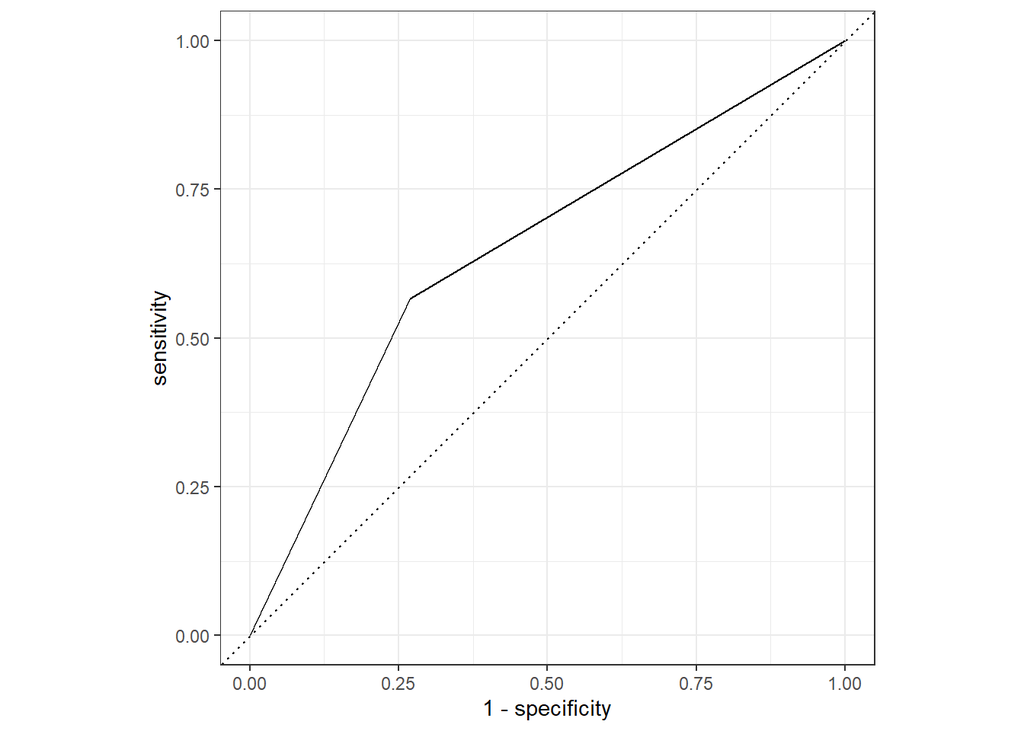

```r
weather_pred2 %>%
  roc_curve(                      # plot ROC curve
    truth = RainTomorrow,
    .pred_Yes,
    event_level = "second"
  ) %>%
  autoplot()
```

```r
weather_pred2 %>%
  roc_auc(                  # get AUC value
    truth = RainTomorrow,
    .pred_Yes,
    event_level = "second"
  )
```

```
## # A tibble: 1 × 3
##   .metric .estimator .estimate
##   <chr>   <chr>          <dbl>
## 1 roc_auc binary         0.649
```

- Create now the ROC curve and get the AUC (area under the curve) value for your second model.

```r
weather_pred3 <- predict(weather_fit2, weather_test, type = "prob") %>%
  bind_cols(weather_test)
```

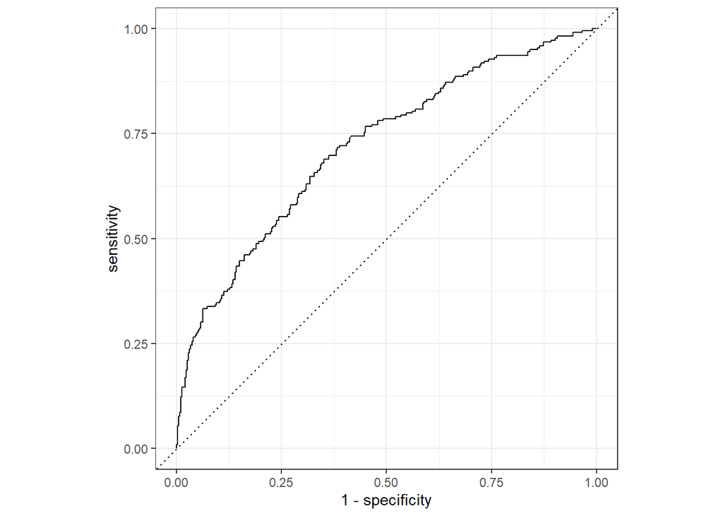

```r
weather_pred3 %>%
  roc_curve(                      # plot ROC curve
    truth = RainTomorrow,
    .pred_Yes,
    event_level = "second"
  ) %>%
  autoplot()
```

```r
weather_pred3 %>%
  roc_auc(                  # get AUC value
    truth = RainTomorrow,
    .pred_Yes,
    event_level = "second"
  )
```

```
## # A tibble: 1 × 3
##   .metric .estimator .estimate
##   <chr>   <chr>          <dbl>
## 1 roc_auc binary         0.719
```

- Which model seems to have a better performance?

```r
cutoff_prob <- 0.3
weather_pred2 %>%
  mutate(
    RainTomorrow      = if_else(RainTomorrow == "Yes", "It rains", "It does not rain"),
    RainTomorrow_pred = if_else(.pred_Yes > cutoff_prob, "Predicted rain", "Predicted no rain")
    ) %>%
  na.omit() %>%
  count(RainTomorrow_pred, RainTomorrow)
```

```
## # A tibble: 4 × 3
##   RainTomorrow_pred RainTomorrow         n
##   <chr>             <chr>            <int>
## 1 Predicted no rain It does not rain   147
## 2 Predicted no rain It rains            61
## 3 Predicted rain    It does not rain    65
## 4 Predicted rain    It rains            88
```

- What is the the false positive rate with `cutoff_prob = 0.3`?

- What about the false negative rate?

# Exercise 4: Extend our model [OPTIONAL]

We will now try to improve our fit by building a model using additional explanatory variables.

1. Let us analyze the various variables in our dataset.
- Is there any categorical variable which is very unbalanced? If so, remove it.
- Is there any numerical variable that has a very small standard deviation for one of the two categories of `RainTomorrow`? If so, remove it.
2. Let’s do some feature engineering: let us transform the variable `Date`. We will use `Ludbridate` again: extract the month and year.
3. Let’s now combine everything into recipes and workflows. Then fit the model on the training data and use the test data for calculating the AUC and plotting the ROC curve.
4. Is this model better than the one we fitted in Exercise 3?